# Executive Summary: Cyclistic Marketing Strategy

Abdullah Aqel

31/12/2025

## Objectives

The goal of this analysis was to identify how annual members and casual riders use the Cyclistic bike-share system differently. By understanding these behaviors, we aim to design a marketing strategy to convert casual riders into long-term, profitable annual members.

## Key Findings

- **Ride Frequency:** Casual riders peak on weekends, while members show high activity during weekday commuting hours (8 AM and 5 PM).

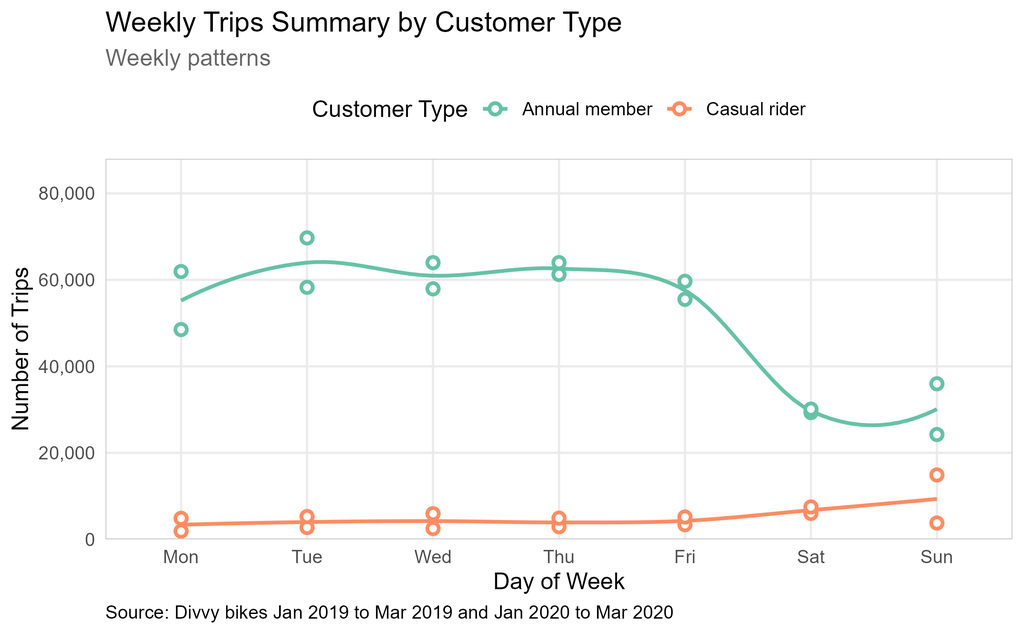

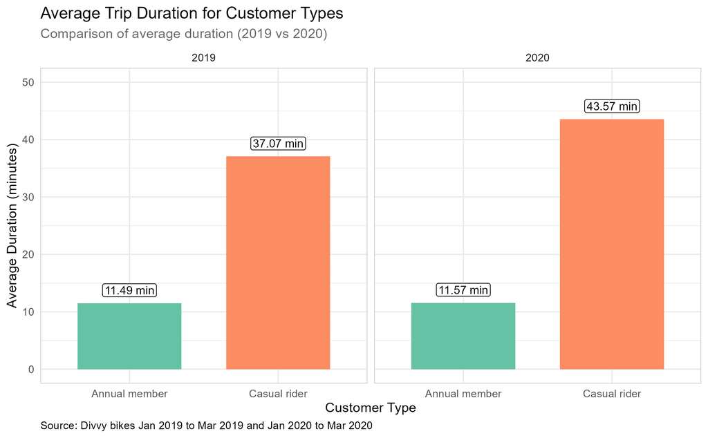

- **Afternoon Surge:** Casual ridership peaks at **3:00 PM**, with the highest sustained traffic occurring between **12:00 PM and 5:00 PM**.

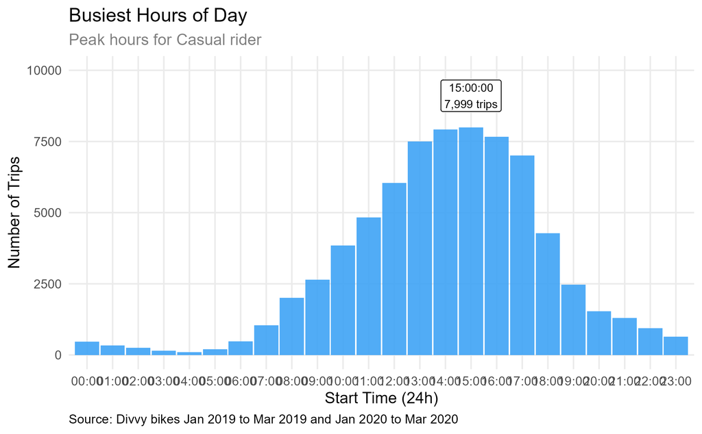

## Recommendations

1. **Introduce Weekend Subscriptions for Casual Riders**

   Leverage the **Weekly Trips Summary by Customer Type** graph, which shows higher bike usage by casual riders on weekends. Offer targeted weekend-only membership plans to convert casual riders into recurring members, emphasizing convenience and cost savings for weekend rides.
2. **Targeted Advertising at High-Traffic Stations for Casual Riders**

   The **Busiest Hours of Day** graph indicates peak bike usage by casual riders between 12 PM and 5 PM. Introduce time-specific promotions, such as discounted rates or bonus ride time for trips taken during these hours.

## Conclution

Casual riders and annual members use Cyclistic for very different reasons. While members use the bikes for daily commuting, casual riders mainly use them for leisure in the afternoons and on weekends. To grow our membership, we should focus our marketing on these high-traffic afternoon windows, showing casual riders how much they could save by switching to an annual plan.